# stud_perf_project

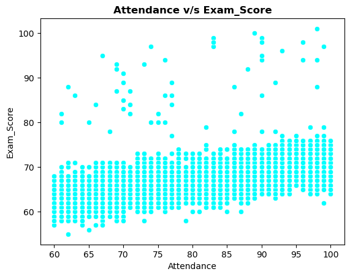

```python
sns.scatterplot(x=df['Attendance'],y=df['Exam_Score'],color='cyan')
plt.title('Attendance v/s Exam_Score',fontweight="bold")
# plt.savefig("Attendance v/s Exam_Score.jpg")
plt.show()


#Q2-the student whose attendance is good .then what is their scores ?
```

```python
#Ans-the students whose attendance is above 90+ their score is the  best
```

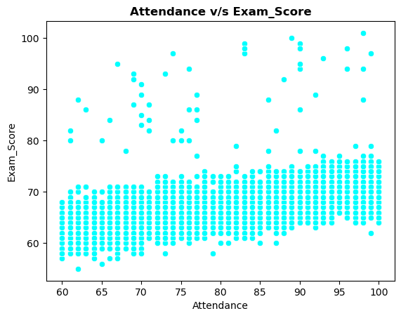

```python
sns.scatterplot(x=df['Attendance'],y=df['Exam_Score'],color='cyan')
plt.title('Attendance v/s Exam_Score',fontweight="bold")
plt.show()
```

**BIVARIATE VARIABLES ANALYSIS**

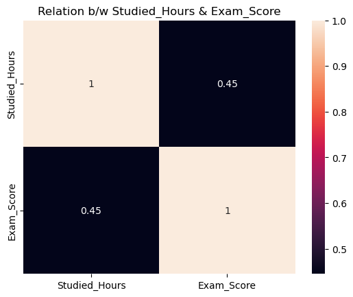

```python
a=df[['Studied_Hours','Exam_Score']].corr()
# print(a)
plt.title('Relation b/w Studied_Hours & Exam_Score')

sns.heatmap(a,annot=True)
plt.savefig("studiedh.jpg")
plt.figure(figsize=(4,3))

plt.show()
```

- So, A few effect on Exam_Score

```
            Attendance  Exam_Score
Attendance    1.000000    0.581072
Exam_Score    0.581072    1.000000
```

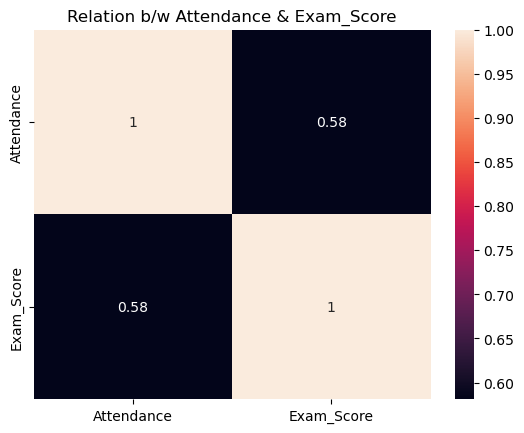

```python
b=df[['Attendance','Exam_Score']].corr()
print(b)
plt.title('Relation b/w Attendance & Exam_Score')
sns.heatmap(b,annot=True)
plt.savefig("Attendance.jpg")
plt.figure(figsize=(4,3))

plt.show()
```

**Corelation is moderate b/w Attendance & Exam_Score**

- So, A few effect on Exam_Score

```python
df.groupby('Parental_Involvement')['Exam_Score'].mean()
```

```
Parental_Involvement
High      68.092767
Low       66.358265
Medium    67.098156
Name: Exam_Score, dtype: float64
```

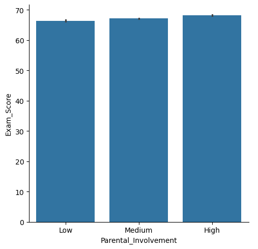

```python
sns.catplot(x='Parental_Involvement',y='Exam_Score',data=df,kind='bar')
plt.show()
```

**No effect on Exam Score by Parental_Involvement**

- Here mean score is almost same

```python
df.groupby('Access_to_Resources')['Exam_Score'].mean()
```

```
Access_to_Resources
High      68.092152
Low       66.203351
Medium    67.134378
Name: Exam_Score, dtype: float64
```

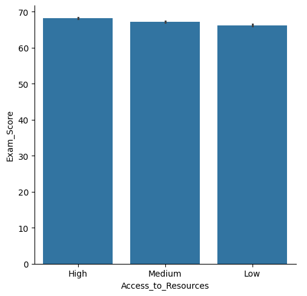

```python
sns.catplot(x='Access_to_Resources',y='Exam_Score',data=df,kind='bar')
plt.savefig('reso.jpg')
plt.show()
```

**No effect on Exam Score by Access_to_Resources**

- Here mean score is almost same

```python
df.groupby('Extracurricular_Activities')['Exam_Score'].mean()
```

```
Extracurricular_Activities
No     66.931435
Yes    67.441849
Name: Exam_Score, dtype: float64
```

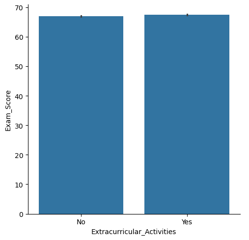

```python
sns.catplot(x='Extracurricular_Activities',y='Exam_Score',data=df,kind='bar')
plt.show()
```

**No effect on Exam Score by Extracurricular_Activities**

- Here mean score is almost same

```python
cor=df[['Sleep_Hours','Exam_Score']].corr()
cor
```

|  | Sleep_Hours | Exam_Score |
| --- | --- | --- |
| Sleep_Hours | 1.000000 | -0.017022 |
| Exam_Score | -0.017022 | 1.000000 |

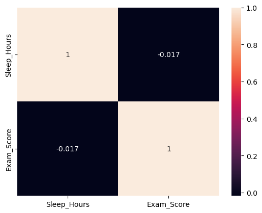

```python
sns.heatmap(cor,annot=True)
plt.savefig('sleephour.jpg')
plt.show()
```

**Here -ve corr. but near to 0 so a few effect on exam score**

```python
score=df[['Previous_Scores','Exam_Score']].corr()
score
```

|  | Previous_Scores | Exam_Score |
| --- | --- | --- |
| Previous_Scores | 1.000000 | 0.175079 |
| Exam_Score | 0.175079 | 1.000000 |

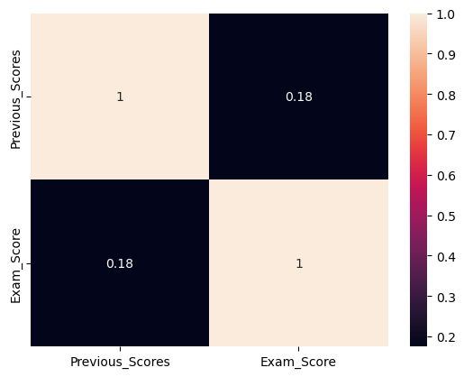

```python
sns.heatmap(score,annot=True)
plt.show()
```

```python
df.groupby('Motivation_Level')['Exam_Score'].mean()
```

```
Motivation_Level
High      67.704321
Low       66.752194
Medium    67.330648
Name: Exam_Score, dtype: float64
```

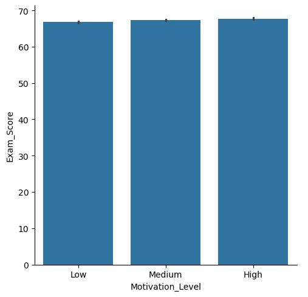

```python
sns.catplot(x='Motivation_Level',y='Exam_Score',data=df,kind='bar')
plt.show()
```

**No effect on exam score from 'Motivation_Level'**

```python
df.groupby('Internet_Access')['Exam_Score'].mean()
```

```
Internet_Access
No     66.535070
Yes    67.292895
Name: Exam_Score, dtype: float64
```

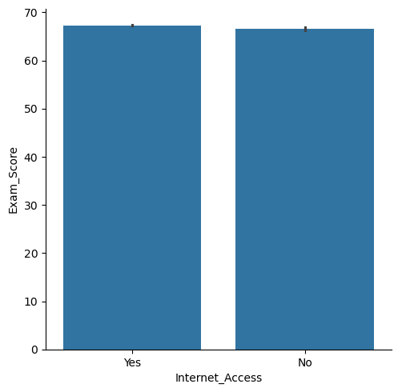

```python
sns.catplot(x='Internet_Access',y='Exam_Score',kind='bar',data=df)
plt.show()
```

**No effect on exam score from 'Internet_Access'**

```python
ts=df[['Tutoring_Sessions','Exam_Score']].corr()
ts
```

|  | Tutoring_Sessions | Exam_Score |
| --- | --- | --- |
| Tutoring_Sessions | 1.000000 | 0.156525 |
| Exam_Score | 0.156525 | 1.000000 |

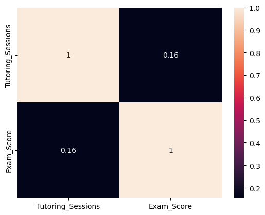

```python
sns.heatmap(ts,annot=True)
plt.show()
```

**A few effect on exam score from 'Tutoring_Sessions'**

```python
df.groupby('Family_Income')['Exam_Score'].mean()
```

```
Family_Income
High      67.842396
Low       66.848428
Medium    67.334959
Name: Exam_Score, dtype: float64
```

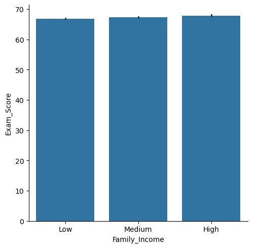

```python
sns.catplot(x='Family_Income',y='Exam_Score',data=df,kind='bar')
plt.show()
```

**No effect on exam score from 'Family_Income'**

```python
df.groupby('Teacher_Quality')['Exam_Score'].mean()
```

```
Teacher_Quality
High      67.676939
Low       66.753425
Medium    67.100175
Name: Exam_Score, dtype: float64
```

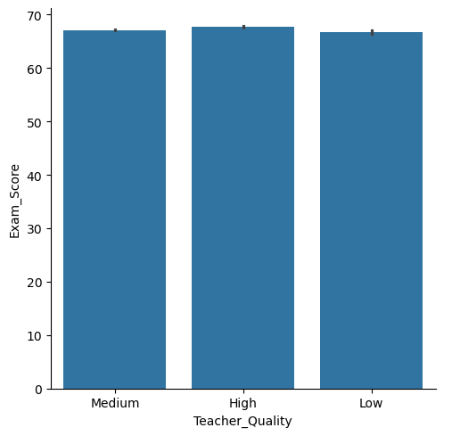

```python
sns.catplot(x='Teacher_Quality',y='Exam_Score',data=df,kind='bar')
plt.show()
```

**No effect on exam score from 'Teacher_Quality'**

```python
df.groupby('School_Type')['Exam_Score'].mean()
```

```
School_Type
Private    67.287705
Public     67.212919
Name: Exam_Score, dtype: float64
```

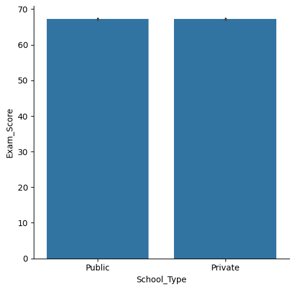

```python
sns.catplot(x='School_Type',y='Exam_Score',data=df,kind='bar')
plt.show()
```

**No effect on exam score from 'School_Type'**

```python
df.groupby('Peer_Influence')['Exam_Score'].mean()
```

```
Peer_Influence
Negative    66.564270
Neutral     67.197917
Positive    67.623199
Name: Exam_Score, dtype: float64
```

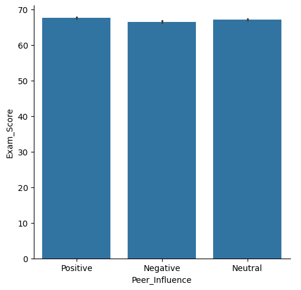

```python
sns.catplot(x='Peer_Influence',y='Exam_Score',data=df,kind='bar')
plt.show()
```

**No effect on exam score from 'Peer_Influence'**

```python
pa=df[['Physical_Activity','Exam_Score']].corr()
pa
```

|  | Physical_Activity | Exam_Score |
| --- | --- | --- |
| Physical_Activity | 1.000000 | 0.027824 |
| Exam_Score | 0.027824 | 1.000000 |

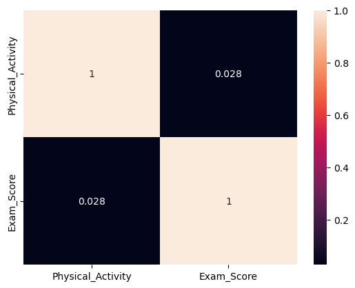

```python
sns.heatmap(pa,annot=True)
plt.show()
```

**NO effect on exam score from 'Physical_Activity'**

```python
df.groupby('Learning_Disabilities')['Exam_Score'].mean()
```

```
Learning_Disabilities
No     67.349120
Yes    66.270504
Name: Exam_Score, dtype: float64
```

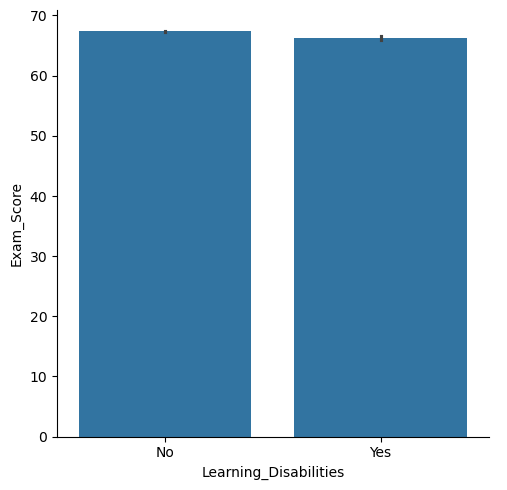

```python
sns.catplot(x='Learning_Disabilities',y='Exam_Score',data=df,kind='bar')
plt.show()
```

**No effect on exam score from 'Learning_Disabilities'**

```python
df.groupby('Parental_Education_Level')['Exam_Score'].mean()
```

```
Parental_Education_Level
College         67.315737
High School     66.897978
Postgraduate    67.970881
Name: Exam_Score, dtype: float64
```

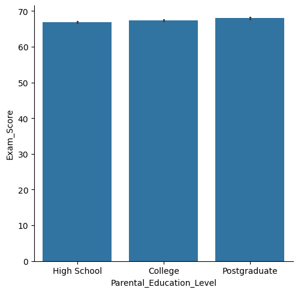

```python
sns.catplot(x='Parental_Education_Level',y='Exam_Score',data=df,kind='bar')
plt.show()
```

**NO effect on exam score from 'Parental_Education_Level'**

```python
df.groupby('Distance_from_Home')['Exam_Score'].mean()
```

```
Distance_from_Home
Far         66.457447
Moderate    66.981481
Near        67.493799
Name: Exam_Score, dtype: float64
```

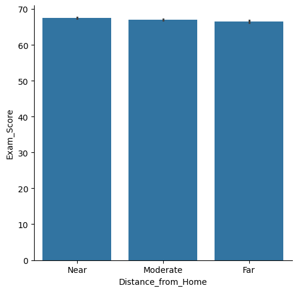

```python
sns.catplot(x='Distance_from_Home',y='Exam_Score',data=df,kind='bar')
plt.show()
```

**No effect on exam score from 'Distance_from_Home'**

```python
df.groupby('Gender')['Exam_Score'].mean()
```

```
Gender
Female    67.244898
Male      67.228894
Name: Exam_Score, dtype: float64
```

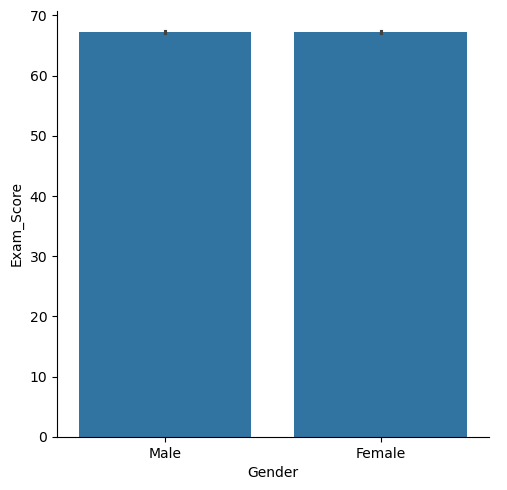

```python
sns.catplot(x='Gender',y='Exam_Score',data=df,kind='bar')
plt.show()
```

**No effect on exam score from 'Gender'**

```python
ef_col=df[['Studied_Hours','Attendance','Sleep_Hours','Tutoring_Sessions','Exam_Score']].corr()
# not_ef_col=[]
ef_col
```

|  | Studied_Hours | Attendance | Sleep_Hours | Tutoring_Sessions | Exam_Score |
| --- | --- | --- | --- | --- | --- |
| Studied_Hours | 1.000000 | -0.009908 | 0.010977 | -0.014282 | 0.445455 |
| Attendance | -0.009908 | 1.000000 | -0.015918 | 0.014324 | 0.581072 |
| Sleep_Hours | 0.010977 | -0.015918 | 1.000000 | -0.012216 | -0.017022 |
| Tutoring_Sessions | -0.014282 | 0.014324 | -0.012216 | 1.000000 | 0.156525 |
| Exam_Score | 0.445455 | 0.581072 | -0.017022 | 0.156525 | 1.000000 |

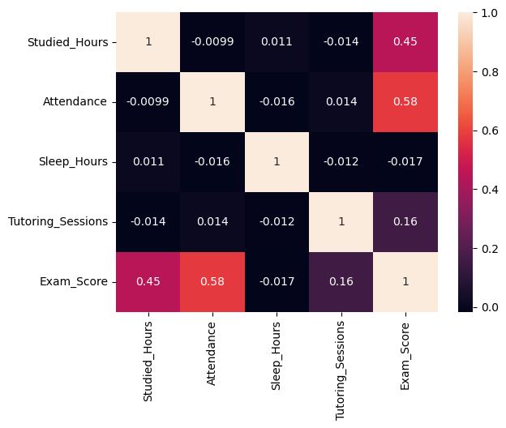

```python
sns.heatmap(ef_col,annot=True)
plt.savefig('finalplot.jpg')
plt.figure(figsize=(4,3))
plt.show()
```

**Conclusion of this project:-**

- 1.Attendance and Studied hours ane most affected to exam score

**Less affected factors are:-**

- 1.Tutorial Session

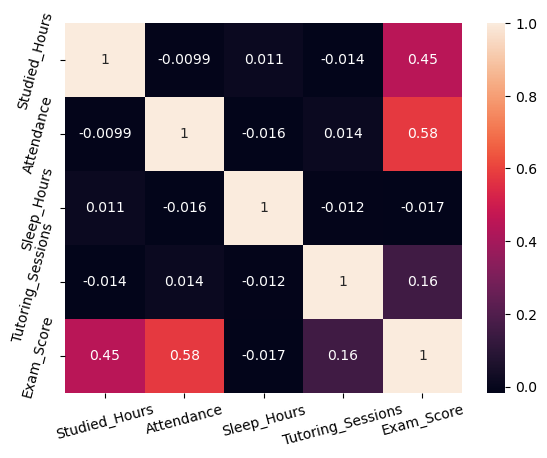

```python
sns.heatmap(ef_col,annot=True)
plt.xticks(rotation=15)
plt.yticks(rotation=75)
plt.savefig('finalplot1.jpg')
# plt.figure(figsize=(4,3))
plt.show()
```